# week8lab

```python
# Data Visualization
# BTech Computer Science Stream
# Week 8: Advanced Visualization
# Kenneth Francis Rodrigues, 240905112, 21/3/2025
```

```python
import numpy as np
import pandas as pd
import matplotlib.pyplot as plt
import seaborn as sns
```

```python
deliveries = pd.read_csv('datasets/deliveries.csv')
deliveries.head()
```

|  | match_id | inning | batting_team | bowling_team | over | ball | batter | bowler | non_striker | batsman_runs | extra_runs | total_runs | extras_type | is_wicket | player_dismissed | dismissal_kind | fielder |
| --- | --- | --- | --- | --- | --- | --- | --- | --- | --- | --- | --- | --- | --- | --- | --- | --- | --- |
| 0 | 335982 | 1 | Kolkata Knight Riders | Royal Challengers Bangalore | 0 | 1 | SC Ganguly | P Kumar | BB McCullum | 0 | 1 | 1 | legbyes | 0 | NaN | NaN | NaN |
| 1 | 335982 | 1 | Kolkata Knight Riders | Royal Challengers Bangalore | 0 | 2 | BB McCullum | P Kumar | SC Ganguly | 0 | 0 | 0 | NaN | 0 | NaN | NaN | NaN |
| 2 | 335982 | 1 | Kolkata Knight Riders | Royal Challengers Bangalore | 0 | 3 | BB McCullum | P Kumar | SC Ganguly | 0 | 1 | 1 | wides | 0 | NaN | NaN | NaN |
| 3 | 335982 | 1 | Kolkata Knight Riders | Royal Challengers Bangalore | 0 | 4 | BB McCullum | P Kumar | SC Ganguly | 0 | 0 | 0 | NaN | 0 | NaN | NaN | NaN |
| 4 | 335982 | 1 | Kolkata Knight Riders | Royal Challengers Bangalore | 0 | 5 | BB McCullum | P Kumar | SC Ganguly | 0 | 0 | 0 | NaN | 0 | NaN | NaN | NaN |

```python
deliveries['batting_team'].unique()
```

```
array(['Kolkata Knight Riders', 'Royal Challengers Bangalore',
       'Chennai Super Kings', 'Kings XI Punjab', 'Rajasthan Royals',
       'Delhi Daredevils', 'Mumbai Indians', 'Deccan Chargers',
       'Kochi Tuskers Kerala', 'Pune Warriors', 'Sunrisers Hyderabad',
       'Rising Pune Supergiants', 'Gujarat Lions',
       'Rising Pune Supergiant', 'Delhi Capitals', 'Punjab Kings',
       'Lucknow Super Giants', 'Gujarat Titans',
       'Royal Challengers Bengaluru'], dtype=object)
```

```python
#1. Find and visualize the total runs scored by each team
```

```python
team_runs = deliveries.groupby('batting_team')['total_runs'].sum()
```

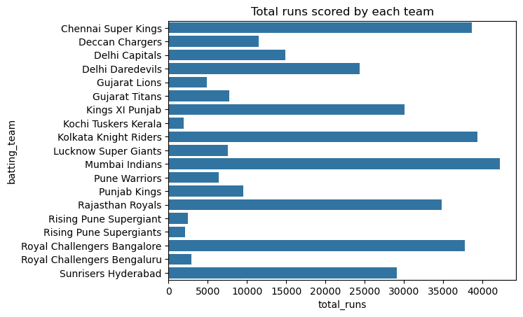

```python
sns.barplot(y=team_runs.index,x=team_runs,orient='h')
plt.title('Total runs scored by each team')
plt.show()
```

I grouped the data with respect to teams and summed up the total runs. Using this data I made a bar plot to visualize.

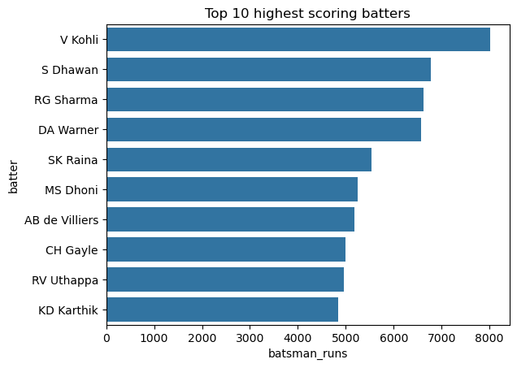

```python
#2. Identify and display the names of the top 10 highest-scoring batters with their total runs scored.
batter_total = deliveries.groupby('batter')['batsman_runs'].sum()
batter_total = batter_total.sort_values(ascending=False)
sns.barplot(x=batter_total[:10],y=batter_total.index[:10],orient='h')
plt.title('Top 10 highest scoring batters')
plt.show()
```

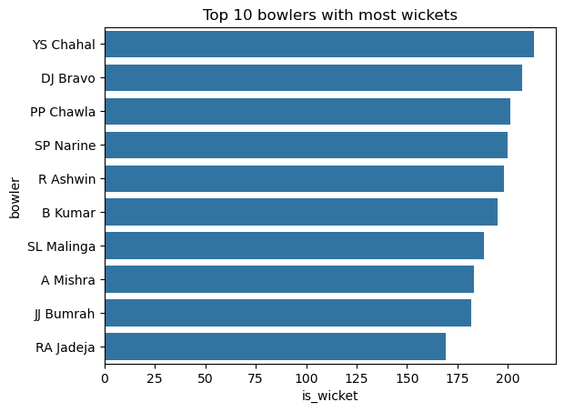

```python
# 3. Find and visualize the top 10 bowlers with the most wickets.
total_wickets = deliveries.groupby('bowler')['is_wicket'].sum()
total_wickets = total_wickets.sort_values(ascending=False)
sns.barplot(x=total_wickets[:10],y=total_wickets.index[:10],orient='h')
plt.title('Top 10 bowlers with most wickets')
plt.show()
```

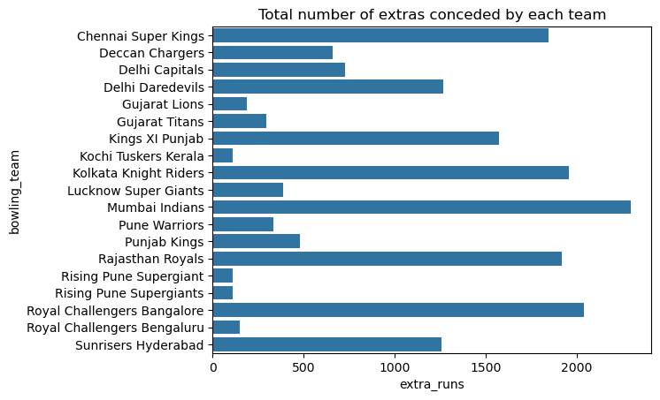

```python
# 4. Tabulate and visualize the total number of extras conceded by each team.
extra = deliveries.groupby('bowling_team')['extra_runs'].sum()
sns.barplot(x=extra,y = extra.index,orient='h')
plt.title('Total number of extras conceded by each team')
plt.show()
```

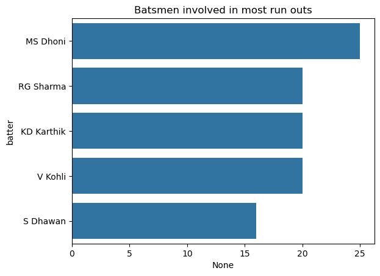

```python
# 5. Tabulate and visualize the batsmen (top 5) involved in the most run-outs.
run_out_rows = deliveries[deliveries['dismissal_kind'] == 'run out']
runout_batter = run_out_rows.groupby('batter').size().sort_values(ascending=False)[:5]
sns.barplot(x=runout_batter,y = runout_batter.index,orient='h')
plt.title('Batsmen involved in most run outs')
plt.show()
```

Filtered the dataset to only the rows where dismissal type was run out. Then grouped by batter and found the size of each group. On sorting in descending order you get batsmen most involved in run outs.

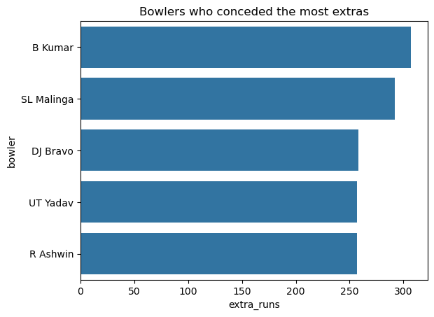

```python
#6. Tabulate and visualize the top 5 bowlers who conceded the most extras.
bowler_extra = deliveries.groupby('bowler')['extra_runs'].sum().sort_values(ascending=False)[:5]
sns.barplot(x = bowler_extra,y= bowler_extra.index,orient='h')
plt.title('Bowlers who conceded the most extras')
plt.show()
```

grouped by bowler and summed up extra runs, then did a bar plot visualization

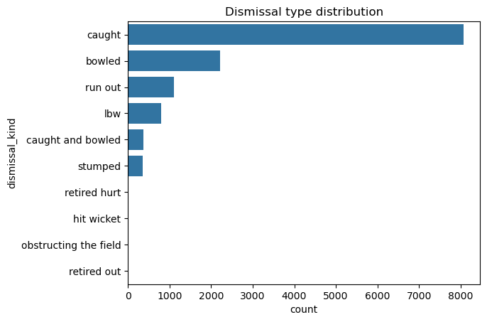

```python
# 7.  Tabulate and visualize the most common dismissal type.
sns.barplot(x=deliveries['dismissal_kind'].value_counts(),y=deliveries['dismissal_kind'].value_counts().index,orient='h')
plt.title('Dismissal type distribution')
plt.show()
```

Caught is the most common dismissal type followed by bowled.

```python
#8. Find and display which of the top 3 overs has the highest run rate.
over_runrate=deliveries.groupby(['match_id','inning','over'])['total_runs'].sum().sort_values(ascending=False)
print('Overs with highest run rates')
over_runrate[:3]
```

```
Overs with highest run rates
```

```
match_id  inning  over
501247    2       2       37
1254076   1       19      37
1304060   2       15      35
Name: total_runs, dtype: int64
```

Grouped by match_id then inning and then over and then summed up the runs per ball to get the run rate in each over. Then sorted in descending order to get the overs with the highest run rate.

```
over
0    0.981663
1    1.173528
2    1.316099
3    1.356538
4    1.369100
5    1.373055
Name: total_runs, dtype: float64
```

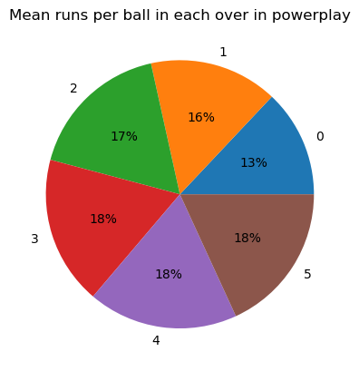

```python
#9. Analyze and visualize powerplay performance (first 6 overs).
powerplay_data = deliveries[deliveries['over'] < 6]
pplay_over=powerplay_data.groupby('over')
pplayruns =pplay_over['total_runs'].mean()
print(pplayruns)
plt.pie(pplayruns,labels=pplayruns.index,autopct='%.0f%%')
plt.title('Mean runs per ball in each over in powerplay')
plt.show()
```

Found the mean runs per ball in each over, the last overs had the most in powerplay and the early ones had the least.

```
over
0    0.033295
1    0.036521
2    0.039200
3    0.040368
4    0.042478
5    0.040018
Name: is_wicket, dtype: float64
```

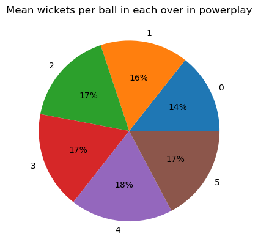

```python
pplaywickets = pplay_over['is_wicket'].mean()
print(pplaywickets)
plt.pie(pplaywickets,labels=pplaywickets.index,autopct='%.0f%%')
plt.title('Mean wickets per ball in each over in powerplay')
plt.show()
```

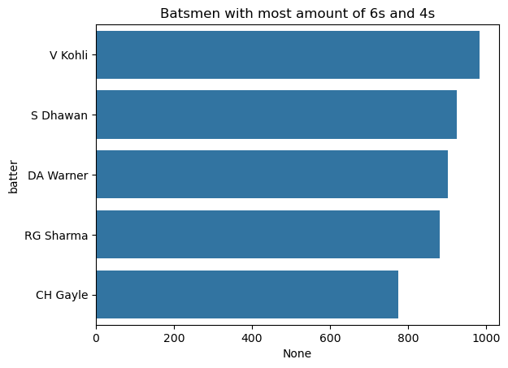

```python
# 10. Tabulate and visualize the top 5 batsmen with the most sixes and fours.
six_four_data = deliveries[(deliveries['total_runs'] == 6) | (deliveries['total_runs'] == 4)]
six_four_counts = six_four_data.groupby('batter').size().sort_values(ascending=False).head(5)
sns.barplot(x=six_four_counts,y=six_four_counts.index,orient='h')
plt.title('Batsmen with most amount of 6s and 4s')
plt.show()
```